# **Santander Customer Satisfaction**

*Matheus C. Andrade*

*August 5, 2021*

## **1. Overview**

[figure not shown]

From frontline support teams to C-suites, customer satisfaction is a key measure of success. Unhappy customers don't stick around. What's more, unhappy customers rarely voice their dissatisfaction before leaving.

Santander Bank is asking [Kagglers](https://www.kaggle.com/c/santander-customer-satisfaction/overview) to help them identify dissatisfied customers early in their relationship. Doing so would allow Santander to take proactive steps to improve a customer's happiness before it's too late.

**Goal:** In this project, it is used the Python language to create a machine learning model that can predict if a customer is satisfied or dissatisfied with their banking experience.

**Features informations:**  
• The dataset has numeric and anonymous variables.  
• The target variable is TARGET column:  
- 0 stands for Satisfied Customers;  
- 1 stands for Dissatisfied Customers.

## **2. Data Collection**

### **2.1 Importing libraries**

```python
# turn off warnings
import warnings
warnings.filterwarnings("ignore")

# for the dataset manipulation and exploration
import pandas as pd
import numpy as np

# intended for create plots
import matplotlib.pyplot as plt
import seaborn as sns

# to display plots of code in input cells
%matplotlib inline
```

### **2.1 Data loading**

```python
# Loading train dataset
df_train = pd.read_csv("data/train.csv", header = 0)
```

```python
df_train.head()
```

|  | ID | var3 | var15 | imp_ent_var16_ult1 | imp_op_var39_comer_ult1 | imp_op_var39_comer_ult3 | imp_op_var40_comer_ult1 | imp_op_var40_comer_ult3 | imp_op_var40_efect_ult1 | imp_op_var40_efect_ult3 | ... | saldo_medio_var33_hace2 | saldo_medio_var33_hace3 | saldo_medio_var33_ult1 | saldo_medio_var33_ult3 | saldo_medio_var44_hace2 | saldo_medio_var44_hace3 | saldo_medio_var44_ult1 | saldo_medio_var44_ult3 | var38 | TARGET |
| --- | --- | --- | --- | --- | --- | --- | --- | --- | --- | --- | --- | --- | --- | --- | --- | --- | --- | --- | --- | --- | --- |
| 0 | 1 | 2 | 23 | 0.0 | 0.0 | 0.0 | 0.0 | 0.0 | 0.0 | 0.0 | ... | 0.0 | 0.0 | 0.0 | 0.0 | 0.0 | 0.0 | 0.0 | 0.0 | 39205.170000 | 0 |
| 1 | 3 | 2 | 34 | 0.0 | 0.0 | 0.0 | 0.0 | 0.0 | 0.0 | 0.0 | ... | 0.0 | 0.0 | 0.0 | 0.0 | 0.0 | 0.0 | 0.0 | 0.0 | 49278.030000 | 0 |
| 2 | 4 | 2 | 23 | 0.0 | 0.0 | 0.0 | 0.0 | 0.0 | 0.0 | 0.0 | ... | 0.0 | 0.0 | 0.0 | 0.0 | 0.0 | 0.0 | 0.0 | 0.0 | 67333.770000 | 0 |
| 3 | 8 | 2 | 37 | 0.0 | 195.0 | 195.0 | 0.0 | 0.0 | 0.0 | 0.0 | ... | 0.0 | 0.0 | 0.0 | 0.0 | 0.0 | 0.0 | 0.0 | 0.0 | 64007.970000 | 0 |
| 4 | 10 | 2 | 39 | 0.0 | 0.0 | 0.0 | 0.0 | 0.0 | 0.0 | 0.0 | ... | 0.0 | 0.0 | 0.0 | 0.0 | 0.0 | 0.0 | 0.0 | 0.0 | 117310.979016 | 0 |

5 rows × 371 columns

```python
# Loading test dataset
df_test = pd.read_csv("data/test.csv", header = 0)
```

```python
df_test.head()
```

|  | ID | var3 | var15 | imp_ent_var16_ult1 | imp_op_var39_comer_ult1 | imp_op_var39_comer_ult3 | imp_op_var40_comer_ult1 | imp_op_var40_comer_ult3 | imp_op_var40_efect_ult1 | imp_op_var40_efect_ult3 | ... | saldo_medio_var29_ult3 | saldo_medio_var33_hace2 | saldo_medio_var33_hace3 | saldo_medio_var33_ult1 | saldo_medio_var33_ult3 | saldo_medio_var44_hace2 | saldo_medio_var44_hace3 | saldo_medio_var44_ult1 | saldo_medio_var44_ult3 | var38 |
| --- | --- | --- | --- | --- | --- | --- | --- | --- | --- | --- | --- | --- | --- | --- | --- | --- | --- | --- | --- | --- | --- |
| 0 | 2 | 2 | 32 | 0.0 | 0.0 | 0.0 | 0.0 | 0.0 | 0.0 | 0.0 | ... | 0.0 | 0.0 | 0.0 | 0.0 | 0.0 | 0.0 | 0.0 | 0.0 | 0.0 | 40532.10 |
| 1 | 5 | 2 | 35 | 0.0 | 0.0 | 0.0 | 0.0 | 0.0 | 0.0 | 0.0 | ... | 0.0 | 0.0 | 0.0 | 0.0 | 0.0 | 0.0 | 0.0 | 0.0 | 0.0 | 45486.72 |
| 2 | 6 | 2 | 23 | 0.0 | 0.0 | 0.0 | 0.0 | 0.0 | 0.0 | 0.0 | ... | 0.0 | 0.0 | 0.0 | 0.0 | 0.0 | 0.0 | 0.0 | 0.0 | 0.0 | 46993.95 |
| 3 | 7 | 2 | 24 | 0.0 | 0.0 | 0.0 | 0.0 | 0.0 | 0.0 | 0.0 | ... | 0.0 | 0.0 | 0.0 | 0.0 | 0.0 | 0.0 | 0.0 | 0.0 | 0.0 | 187898.61 |
| 4 | 9 | 2 | 23 | 0.0 | 0.0 | 0.0 | 0.0 | 0.0 | 0.0 | 0.0 | ... | 0.0 | 0.0 | 0.0 | 0.0 | 0.0 | 0.0 | 0.0 | 0.0 | 0.0 | 73649.73 |

5 rows × 370 columns

## **3. Exploratory Data Analysis & Data preprocessing (Data Wrangling)**

### **3.1 Train dataset**

```python
# Drop first column, ID column
df_train = df_train.iloc[: , 1:]
```

```python
df_train.shape
```

```
(76020, 370)
```

```python
# Drop first column of dataframe, ID column
df_train = df_train.iloc[: , 1:]
```

```python
# Counting duplicate rows
df_train.duplicated().sum()
```

```
4849
```

```python
# Removing duplicate rows
df_train = df_train.drop_duplicates()
```

```python
df_train.shape
```

```
(71171, 369)
```

```python
# Detecting missing values
df_train.isna().sum().sum() # df_train.isnull().values.any()
```

```
0
```

No missing values

```python
# Data type check
df_train.dtypes.value_counts()
```

```
int64      258
float64    111
dtype: int64
```

#### **3.1.1 Target feature**

```python
df_train['TARGET'].value_counts()
```

```
0    68357
1     2814
Name: TARGET, dtype: int64
```

|  | TARGET | Frequency (%) |
| --- | --- | --- |
| Satisfied Customers | 68357 | 96.046142 |
| Dissatisfied Customers | 2814 | 3.953858 |

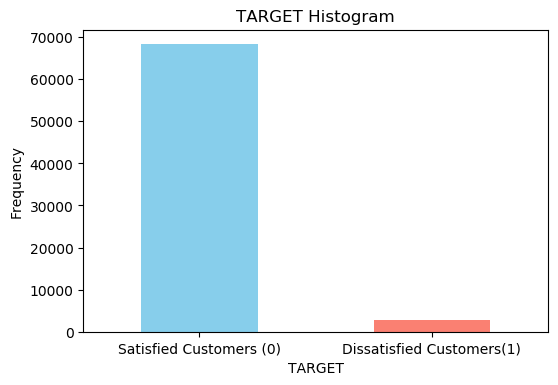

```python
plt.rcParams['figure.dpi'] = 100
# Target variable distribution
pd.value_counts(df_train['TARGET']).plot.bar(color=['skyblue', 'salmon'])
plt.title('TARGET Histogram')
plt.xlabel('TARGET')
plt.ylabel('Frequency')
plt.xticks([0, 1],['Satisfied Customers (0)', 'Dissatisfied Customers(1)'], rotation=0)
plt.template = 'plotly_white'

# # Target variable frequency
df_targetPercent = pd.DataFrame(df_train['TARGET'].value_counts())
df_targetPercent['Frequency (%)'] = 100*df_targetPercent['TARGET']/df_train.shape[0]
df_targetPercent = df_targetPercent.rename(index={0: 'Satisfied Customers', 1: 'Dissatisfied Customers'})
df_targetPercent
```

There is an unequal distribution of classes in the training dataset, this is a imbalanced dataset. Imbalanced data typically refers to a problem with classification problems where the classes are not represented equally.

### **3.2 Feature selection**

#### **3.2.1 Removing features with low variance**

It removes all features whose variance doesn’t meet some threshold. By default, it removes all zero-variance features, i.e. features that have the same value in all samples.

```python
# import feature selector that removes all low-variance features
from sklearn.feature_selection import VarianceThreshold

# function for removing features with 0 variance
def variance_threshold_selector(data):
    selector = VarianceThreshold() # removing all features with null variance/zero variance
    selector.fit(data)
    return data[data.columns[selector.get_support(indices=True)]]
```

```python
df_train = variance_threshold_selector(df_train)
```

```python
df_train.shape # 34 features were found to have zero variance and these were all removed.
```

```
(71171, 335)
```

```python
df_train
```

|  | var15 | imp_ent_var16_ult1 | imp_op_var39_comer_ult1 | imp_op_var39_comer_ult3 | imp_op_var40_comer_ult1 | imp_op_var40_comer_ult3 | imp_op_var40_efect_ult1 | imp_op_var40_efect_ult3 | imp_op_var40_ult1 | imp_op_var41_comer_ult1 | ... | saldo_medio_var33_hace2 | saldo_medio_var33_hace3 | saldo_medio_var33_ult1 | saldo_medio_var33_ult3 | saldo_medio_var44_hace2 | saldo_medio_var44_hace3 | saldo_medio_var44_ult1 | saldo_medio_var44_ult3 | var38 | TARGET |
| --- | --- | --- | --- | --- | --- | --- | --- | --- | --- | --- | --- | --- | --- | --- | --- | --- | --- | --- | --- | --- | --- |
| 0 | 23 | 0.0 | 0.00 | 0.00 | 0.0 | 0.0 | 0.0 | 0.0 | 0.0 | 0.00 | ... | 0.0 | 0.0 | 0.0 | 0.0 | 0.0 | 0.0 | 0.0 | 0.0 | 39205.170000 | 0 |
| 1 | 34 | 0.0 | 0.00 | 0.00 | 0.0 | 0.0 | 0.0 | 0.0 | 0.0 | 0.00 | ... | 0.0 | 0.0 | 0.0 | 0.0 | 0.0 | 0.0 | 0.0 | 0.0 | 49278.030000 | 0 |
| 2 | 23 | 0.0 | 0.00 | 0.00 | 0.0 | 0.0 | 0.0 | 0.0 | 0.0 | 0.00 | ... | 0.0 | 0.0 | 0.0 | 0.0 | 0.0 | 0.0 | 0.0 | 0.0 | 67333.770000 | 0 |
| 3 | 37 | 0.0 | 195.00 | 195.00 | 0.0 | 0.0 | 0.0 | 0.0 | 0.0 | 195.00 | ... | 0.0 | 0.0 | 0.0 | 0.0 | 0.0 | 0.0 | 0.0 | 0.0 | 64007.970000 | 0 |
| 4 | 39 | 0.0 | 0.00 | 0.00 | 0.0 | 0.0 | 0.0 | 0.0 | 0.0 | 0.00 | ... | 0.0 | 0.0 | 0.0 | 0.0 | 0.0 | 0.0 | 0.0 | 0.0 | 117310.979016 | 0 |
| ... | ... | ... | ... | ... | ... | ... | ... | ... | ... | ... | ... | ... | ... | ... | ... | ... | ... | ... | ... | ... | ... |
| 76014 | 39 | 0.0 | 375.99 | 405.33 | 0.0 | 0.0 | 0.0 | 0.0 | 0.0 | 375.99 | ... | 0.0 | 0.0 | 0.0 | 0.0 | 0.0 | 0.0 | 0.0 | 0.0 | 90214.170000 | 0 |
| 76015 | 48 | 0.0 | 0.00 | 0.00 | 0.0 | 0.0 | 0.0 | 0.0 | 0.0 | 0.00 | ... | 0.0 | 0.0 | 0.0 | 0.0 | 0.0 | 0.0 | 0.0 | 0.0 | 60926.490000 | 0 |
| 76016 | 39 | 0.0 | 0.00 | 0.00 | 0.0 | 0.0 | 0.0 | 0.0 | 0.0 | 0.00 | ... | 0.0 | 0.0 | 0.0 | 0.0 | 0.0 | 0.0 | 0.0 | 0.0 | 118634.520000 | 0 |
| 76017 | 23 | 0.0 | 0.00 | 0.00 | 0.0 | 0.0 | 0.0 | 0.0 | 0.0 | 0.00 | ... | 0.0 | 0.0 | 0.0 | 0.0 | 0.0 | 0.0 | 0.0 | 0.0 | 74028.150000 | 0 |
| 76018 | 25 | 0.0 | 0.00 | 0.00 | 0.0 | 0.0 | 0.0 | 0.0 | 0.0 | 0.00 | ... | 0.0 | 0.0 | 0.0 | 0.0 | 0.0 | 0.0 | 0.0 | 0.0 | 84278.160000 | 0 |

71171 rows × 335 columns

#### **3.2.2 Tree-based feature selection**

"Tree-based estimators can be used to compute impurity-based feature importances, which in turn can be used to discard irrelevant features. Bagged decision trees like Random Forest and Extra Trees can be used to estimate the [importance of features](https://machinelearningmastery.com/feature-selection-machine-learning-python/)", so we will use ExtraTreesClassifier.

"[Extremely Randomized Trees Classifier (Extra Trees Classifier)](https://www.geeksforgeeks.org/ml-extra-tree-classifier-for-feature-selection/) is a type of ensemble learning technique which aggregates the results of multiple de-correlated decision trees collected in a “forest” to output it’s classification result".

```python
from sklearn.ensemble import ExtraTreesClassifier

# Separating the dataset into input (X) and output (Y)
X = df_train.iloc[:, :-1] # Drop last column of a dataframe
y = df_train.TARGET # get last column of a dataframe #df.iloc[:,-1:]

# Feature Selection Model Creation
featureSelection_model = ExtraTreesClassifier(random_state=123)
featureSelection_model.fit(X, y)

# Convert the result to dataframe
df_featuresSelected = pd.DataFrame(df_train.columns,columns=['Columns'])
df_featuresSelected['Score'] = pd.DataFrame(featureSelection_model.feature_importances_.astype(float))

# Sort by score
result = df_featuresSelected.sort_values('Score',ascending=False)
```

```python
result[result['Score'] > 0].sum()
# The sum of columns that have worthiness bigger than zero is equal to 1.
```

```
Columns    var38var15saldo_medio_var5_hace3saldo_medio_va...
Score                                                      1
dtype: object
```

```python
result[result['Score'] <= 0].shape
```

```
(26, 2)
```

There are 26 columns that have significance less than or equal to zero for the dataset. So we'll remove them as well.

```python
# Selection of pertinent columns
cols_of_interest = result[result['Score'] > 0]['Columns']

# Adding target column label to the columns of interest
cols_of_interest = cols_of_interest.append(pd.Series(['TARGET']))
```

```python
# Getting only columns of interest in training df
df_trainFS = df_train[cols_of_interest]
```

```python
df_trainFS
```

|  | var38 | var15 | saldo_medio_var5_hace3 | saldo_medio_var5_ult3 | num_var45_ult3 | num_var45_hace3 | num_var45_hace2 | num_var22_ult3 | saldo_medio_var5_hace2 | num_var45_ult1 | ... | num_aport_var33_ult1 | delta_imp_trasp_var33_out_1y3 | delta_imp_amort_var18_1y3 | saldo_var6 | num_op_var40_hace3 | delta_num_trasp_var33_out_1y3 | saldo_medio_var13_medio_ult1 | ind_var18 | delta_imp_amort_var34_1y3 | TARGET |
| --- | --- | --- | --- | --- | --- | --- | --- | --- | --- | --- | --- | --- | --- | --- | --- | --- | --- | --- | --- | --- | --- |
| 0 | 39205.170000 | 23 | 0.00 | 0.00 | 0 | 0 | 0 | 0 | 0.00 | 0 | ... | 0 | 0 | 0 | 0.0 | 0 | 0 | 0 | 0 | 0 | 0 |
| 1 | 49278.030000 | 34 | 88.89 | 0.00 | 0 | 0 | 0 | 0 | 0.00 | 0 | ... | 0 | 0 | 0 | 0.0 | 0 | 0 | 0 | 0 | 0 | 0 |
| 2 | 67333.770000 | 23 | 0.18 | 2.07 | 0 | 0 | 0 | 0 | 3.00 | 0 | ... | 0 | 0 | 0 | 0.0 | 0 | 0 | 0 | 0 | 0 | 0 |
| 3 | 64007.970000 | 37 | 0.00 | 138.84 | 48 | 3 | 27 | 3 | 186.09 | 18 | ... | 0 | 0 | 0 | 0.0 | 0 | 0 | 0 | 0 | 0 | 0 |
| 4 | 117310.979016 | 39 | 0.30 | 13501.47 | 0 | 0 | 0 | 9 | 3.00 | 0 | ... | 0 | 0 | 0 | 0.0 | 0 | 0 | 0 | 0 | 0 | 0 |
| ... | ... | ... | ... | ... | ... | ... | ... | ... | ... | ... | ... | ... | ... | ... | ... | ... | ... | ... | ... | ... | ... |
| 76014 | 90214.170000 | 39 | 169.35 | 1025.37 | 99 | 12 | 36 | 12 | 217.74 | 51 | ... | 0 | 0 | 0 | 0.0 | 0 | 0 | 0 | 0 | 0 | 0 |
| 76015 | 60926.490000 | 48 | 0.00 | 0.00 | 0 | 0 | 0 | 0 | 0.00 | 0 | ... | 0 | 0 | 0 | 0.0 | 0 | 0 | 0 | 0 | 0 | 0 |
| 76016 | 118634.520000 | 39 | 0.00 | 0.00 | 48 | 3 | 36 | 24 | 130.65 | 9 | ... | 0 | 0 | 0 | 0.0 | 0 | 0 | 0 | 0 | 0 | 0 |
| 76017 | 74028.150000 | 23 | 0.00 | 3.00 | 0 | 0 | 0 | 0 | 3.00 | 0 | ... | 0 | 0 | 0 | 0.0 | 0 | 0 | 0 | 0 | 0 | 0 |
| 76018 | 84278.160000 | 25 | 1.74 | 2.58 | 0 | 0 | 0 | 0 | 3.00 | 0 | ... | 0 | 0 | 0 | 0.0 | 0 | 0 | 0 | 0 | 0 | 0 |

71171 rows × 309 columns

```python
# Generate descriptive statistics.
df_trainFS.describe()
```

|  | var38 | var15 | saldo_medio_var5_hace3 | saldo_medio_var5_ult3 | num_var45_ult3 | num_var45_hace3 | num_var45_hace2 | num_var22_ult3 | saldo_medio_var5_hace2 | num_var45_ult1 | ... | num_aport_var33_ult1 | delta_imp_trasp_var33_out_1y3 | delta_imp_amort_var18_1y3 | saldo_var6 | num_op_var40_hace3 | delta_num_trasp_var33_out_1y3 | saldo_medio_var13_medio_ult1 | ind_var18 | delta_imp_amort_var34_1y3 | TARGET |
| --- | --- | --- | --- | --- | --- | --- | --- | --- | --- | --- | --- | --- | --- | --- | --- | --- | --- | --- | --- | --- | --- |
| count | 7.117100e+04 | 71171.000000 | 7.117100e+04 | 71171.000000 | 71171.000000 | 71171.000000 | 71171.000000 | 71171.000000 | 71171.000000 | 71171.000000 | ... | 71171.000000 | 7.117100e+04 | 7.117100e+04 | 71171.000000 | 71171.000000 | 7.117100e+04 | 71171.000000 | 71171.000000 | 7.117100e+04 | 71171.000000 |
| mean | 1.171340e+05 | 33.559455 | 9.519084e+02 | 1119.886224 | 14.568532 | 4.151846 | 5.756994 | 3.248612 | 1686.190237 | 4.659693 | ... | 0.000337 | 1.405067e+05 | 2.810133e+05 | 0.442714 | 0.001096 | 1.405067e+05 | 0.547976 | 0.000028 | 2.810133e+05 | 0.039539 |
| std | 1.882831e+05 | 13.106936 | 1.021710e+04 | 8459.678203 | 34.226905 | 10.716077 | 14.911929 | 6.361837 | 12548.327742 | 14.842786 | ... | 0.035559 | 3.748422e+07 | 5.301032e+07 | 85.880885 | 0.186818 | 3.748422e+07 | 117.403567 | 0.005301 | 5.301032e+07 | 0.194874 |
| min | 5.163750e+03 | 5.000000 | -8.040000e+00 | -476.070000 | 0.000000 | 0.000000 | 0.000000 | 0.000000 | -128.370000 | 0.000000 | ... | 0.000000 | 0.000000e+00 | 0.000000e+00 | 0.000000 | 0.000000 | 0.000000e+00 | 0.000000 | 0.000000 | 0.000000e+00 | 0.000000 |
| 25% | 6.585643e+04 | 23.000000 | 0.000000e+00 | 0.000000 | 0.000000 | 0.000000 | 0.000000 | 0.000000 | 0.000000 | 0.000000 | ... | 0.000000 | 0.000000e+00 | 0.000000e+00 | 0.000000 | 0.000000 | 0.000000e+00 | 0.000000 | 0.000000 | 0.000000e+00 | 0.000000 |
| 50% | 1.001368e+05 | 28.000000 | 1.050000e+00 | 2.790000 | 3.000000 | 0.000000 | 0.000000 | 0.000000 | 3.000000 | 0.000000 | ... | 0.000000 | 0.000000e+00 | 0.000000e+00 | 0.000000 | 0.000000 | 0.000000e+00 | 0.000000 | 0.000000 | 0.000000e+00 | 0.000000 |
| 75% | 1.228413e+05 | 40.000000 | 1.599000e+01 | 89.595000 | 15.000000 | 3.000000 | 6.000000 | 3.000000 | 90.000000 | 3.000000 | ... | 0.000000 | 0.000000e+00 | 0.000000e+00 | 0.000000 | 0.000000 | 0.000000e+00 | 0.000000 | 0.000000 | 0.000000e+00 | 0.000000 |
| max | 2.203474e+07 | 105.000000 | 1.542339e+06 | 544365.570000 | 801.000000 | 339.000000 | 342.000000 | 234.000000 | 812137.260000 | 510.000000 | ... | 6.000000 | 1.000000e+10 | 1.000000e+10 | 19531.800000 | 48.000000 | 1.000000e+10 | 30000.000000 | 1.000000 | 1.000000e+10 | 1.000000 |

8 rows × 309 columns

Descriptive statistics include those that summarize the central tendency, dispersion and shape of a dataset’s distribution, excluding NaN values.

```python
# Detecting missing values in the new dataset
df_trainFS.isna().sum().sum() # df_train.isnull().values.any()
```

```
0
```

### **3.3 Correlation Analysis**

```python
# Since there are many variables, let's get justcolumns in which its scores sums represents about 82% of dataset.
result[result['Score'] > 0.008].sum()
```

```
Columns    var38var15saldo_medio_var5_hace3saldo_medio_va...
Score                                               0.819848
dtype: object
```

```python
# so, instead of analysing 309 columns, we will analyse just the more important columns. They are 21 columns.
result[result['Score'] > 0.008].shape
```

```
(21, 2)
```

```python
# the 21 of most important columns and their respective score to the dataset
result[result['Score'] > 0.008]
```

|  | Columns | Score |
| --- | --- | --- |
| 333 | var38 | 0.409930 |
| 0 | var15 | 0.153292 |
| 295 | saldo_medio_var5_hace3 | 0.025690 |
| 297 | saldo_medio_var5_ult3 | 0.024887 |
| 293 | num_var45_ult3 | 0.020091 |
| 291 | num_var45_hace3 | 0.018750 |
| 290 | num_var45_hace2 | 0.016215 |
| 248 | num_var22_ult3 | 0.013850 |
| 294 | saldo_medio_var5_hace2 | 0.013380 |
| 292 | num_var45_ult1 | 0.012654 |
| 250 | num_med_var45_ult3 | 0.012291 |
| 246 | num_var22_hace3 | 0.011140 |
| 170 | saldo_var42 | 0.011134 |
| 163 | saldo_var30 | 0.010975 |
| 296 | saldo_medio_var5_ult1 | 0.010905 |
| 245 | num_var22_hace2 | 0.010710 |
| 147 | saldo_var5 | 0.010011 |
| 251 | num_meses_var5_ult3 | 0.009407 |
| 172 | var36 | 0.008234 |
| 260 | num_meses_var39_vig_ult3 | 0.008177 |
| 247 | num_var22_ult1 | 0.008123 |

```python
# Getting 21 labels of most important columns
cols_corr = result[0:21]['Columns']

# Getting target label
cols_corr = cols_corr.append(pd.Series(['TARGET']))

# Getting only pertinent columns to the correlation analysis in training df
df_corr = df_train[cols_corr]
```

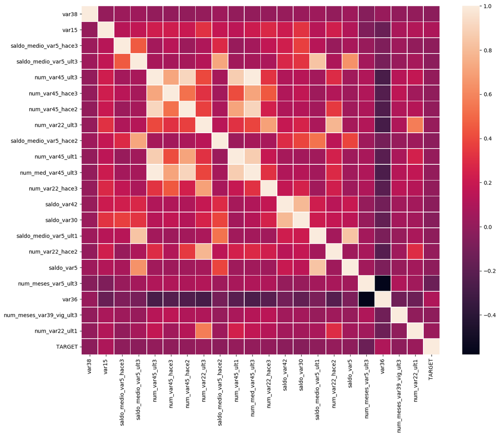

```python
# Correlation Analysis

# Applying the correlation: compute pairwise correlation of columns, excluding NA/null values.
df_corr_ = df_corr.corr()

# Correlation plotting with a heatmap
f, ax = plt.subplots(figsize=(15, 12))
sns.heatmap(df_corr_,linewidths=.5, ax=ax);
```

### **3.4 Most scored features analysis**

```python
result[result['Score'] > 0.02]
```

|  | Columns | Score |
| --- | --- | --- |
| 333 | var38 | 0.409930 |
| 0 | var15 | 0.153292 |
| 295 | saldo_medio_var5_hace3 | 0.025690 |
| 297 | saldo_medio_var5_ult3 | 0.024887 |
| 293 | num_var45_ult3 | 0.020091 |

It will be analyzed just two variables: var38 and var15, since their scores sums represents about 55% of dataset, and the others represent no more than 3%.

```python
#df_analysis = df_trainFS
```

#### **3.4.1 var38**

```python
# 'var38' descriptive statistics.
df_trainFS.var38.describe()
```

```
count    7.117100e+04
mean     1.171340e+05
std      1.882831e+05
min      5.163750e+03
25%      6.585643e+04
50%      1.001368e+05
75%      1.228413e+05
max      2.203474e+07
Name: var38, dtype: float64
```

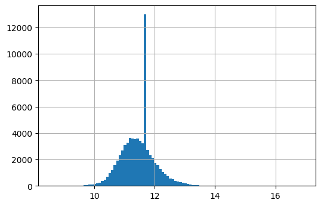

```python
# 'var38' histogram
df_trainFS.var38.map(np.log).hist(bins=100);
```

There is a value with many more occurrences than the others

```python
# Viewing the most common variable value

df_trainFS.var38.value_counts()
```

```
117310.979016    10069
451931.220000       16
463625.160000       12
104563.800000       11
288997.440000       10
                 ...
49273.950000         1
261810.900000        1
49898.280000         1
39156.810000         1
159395.520000        1
Name: var38, Length: 57736, dtype: int64
```

The value 117310.979016 appears 10069 times (much higher than the other values).

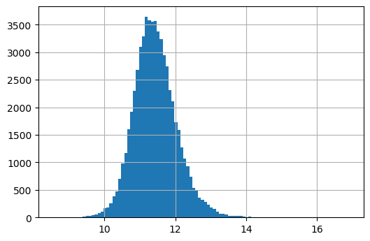

```python
# Viewing var38 histogram without the most common variable value
df_trainFS.loc[~np.isclose(df_trainFS.var38, 117310.979016), 'var38'].map(np.log).hist(bins=100);
```

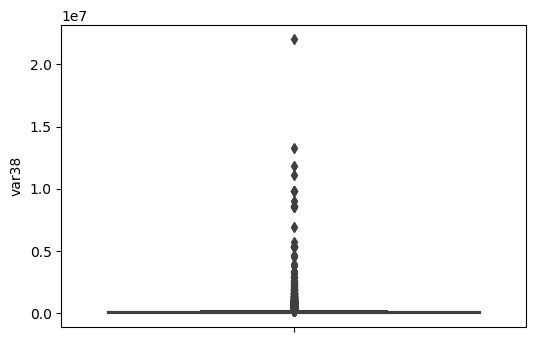

```python
# var38 Boxplot
sns.boxplot(x=df_trainFS["var38"], orient='v') # df_trainFS.boxplot(column=['var38'])
```

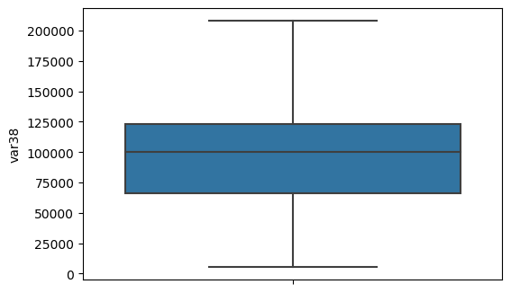

```python
# var38 Boxplot without outliers
sns.boxplot(x=df_trainFS["var38"], showfliers=False, orient='v') # df_trainFS.boxplot(column=['var38'], showfliers=False)
```

#### **3.4.2 var15**

```python
# 'var15' descriptive statistics.
df_trainFS.var15.describe()
```

```
count    71171.000000
mean        33.559455
std         13.106936
min          5.000000
25%         23.000000
50%         28.000000
75%         40.000000
max        105.000000
Name: var15, dtype: float64
```

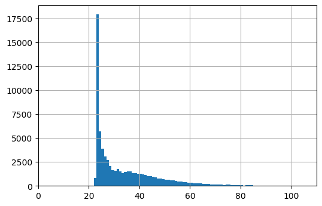

```python
# 'var15' histogram
df_trainFS.var15.hist(bins=100);
```

According to variables information at Kaggle's forum, this variable seems to be the age of the customer. Notice that there is a value with many more occurrences than the others.

```python
# Viewing the most common values
var15_rel = df_trainFS.var15.value_counts(normalize=True).head(10)
var15_abs = df_trainFS.var15.value_counts().head(10)
var15_abs_rel = pd.DataFrame({'Age':var15_abs.index,
                              'var15_abs': var15_abs,
                              'var15_rel':var15_rel,}).reset_index(drop=True)
#pd.DataFrame(dict(Age=var15_abs.index, var15_abs = var15_abs, var15_rel = var15_rel)).reset_index(drop=True)
var15_abs_rel
```

|  | Age | var15_abs | var15_rel |
| --- | --- | --- | --- |
| 0 | 23 | 17936 | 0.252013 |
| 1 | 24 | 5717 | 0.080328 |
| 2 | 25 | 3901 | 0.054812 |
| 3 | 26 | 3083 | 0.043318 |
| 4 | 27 | 2684 | 0.037712 |
| 5 | 28 | 2063 | 0.028987 |
| 6 | 31 | 1739 | 0.024434 |
| 7 | 29 | 1654 | 0.023240 |
| 8 | 30 | 1581 | 0.022214 |
| 9 | 32 | 1522 | 0.021385 |

```python
var15_abs_rel['var15_rel'].sum()
```

```
0.5884419215691785
```

The most common age is 23, which represents a quarter of all customers. It should also be noted that most customers are between 23 and 32 years old, which represents around 58% of total customers.

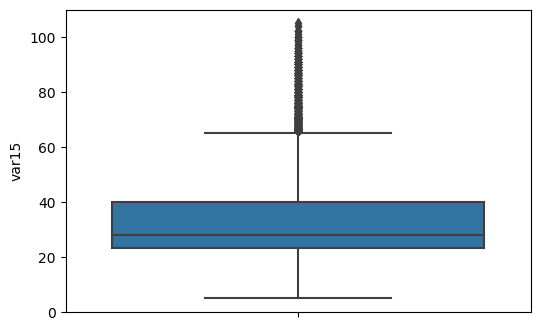

```python
# var15 Boxplot
sns.boxplot(x=df_trainFS["var15"], orient='v') # df_trainFS.boxplot(column=['var38'])
```

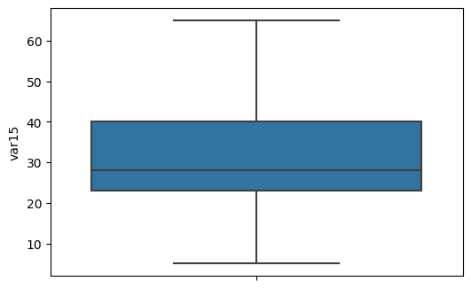

```python
# var15 Boxplot without outliers
sns.boxplot(x=df_trainFS["var15"], showfliers=False, orient='v') # df_trainFS.boxplot(column=['var38'], showfliers=False)
```

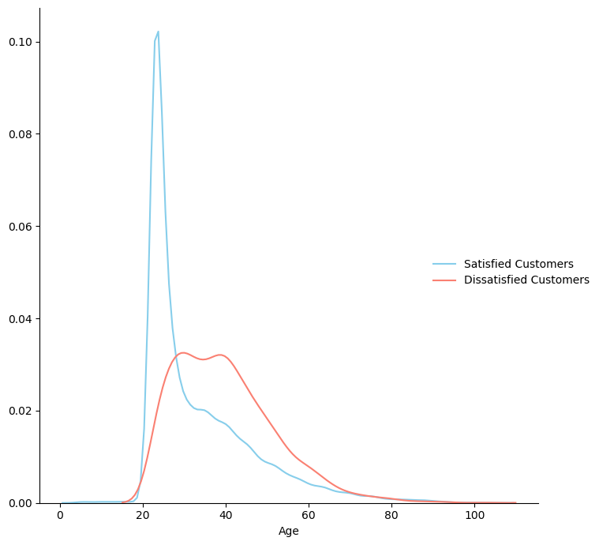

```python
# Kernel distribution estimation plot
g = sns.FacetGrid(df_trainFS, hue="TARGET", height=7, hue_kws={'color': ['skyblue', 'salmon']}) \
   .map(sns.kdeplot, "var15") \
   .add_legend()

g._legend.texts[0].set_text("Satisfied Customers")
g._legend.texts[1].set_text("Dissatisfied Customers")
g._legend.set_title("")
g.axes[0,0].set_xlabel('Age')   #plt.xlabel("Age")
#g.axes[0,0].set_ylabel('Count') #plt.ylabel("Count")
```

Older people tend to be more dissatisfied.

## **4. Data Modelling**

#### Data Splitting

```python
# Import library for split arrays into random train and test subsets
from sklearn.model_selection import train_test_split

# Split dataset into input and output variables
X = df_trainFS.iloc[:,:-1]
y = df_trainFS.TARGET

# Sizes of train and test dataset
test_size = 0.3

# Setting a seed to allow the same experiment result to be reproducible
seed = 123
```

### **4.1 Comparison of machine-learning algorithms**

Now, let's test some classification algorithms to see which will perform best.

```
LR: 0.605144 (0.013137)
RF: 0.751351 (0.009078)
LDA: 0.788330 (0.007285)
KNN: 0.593689 (0.010378)
CART: 0.552014 (0.008265)
XGBoost: 0.822892 (0.005379)
```

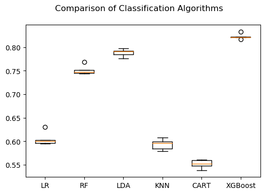

```python
# Classification models creation

# libraries
from sklearn.preprocessing import MinMaxScaler
from sklearn.preprocessing import StandardScaler

from sklearn.model_selection import KFold
from sklearn.model_selection import cross_val_score
from sklearn.linear_model import LogisticRegression
from sklearn.ensemble import RandomForestClassifier
from sklearn.tree import DecisionTreeClassifier
from sklearn.neighbors import KNeighborsClassifier
from sklearn.discriminant_analysis import LinearDiscriminantAnalysis
from sklearn.naive_bayes import GaussianNB
from sklearn.svm import SVC
from xgboost import XGBClassifier


# Transform features by scaling each feature to a given range.
X_MinMaxStandard = MinMaxScaler().fit_transform(X)

# Standardize features by removing the mean and scaling to unit variance
X_MinMaxStandard = StandardScaler().fit_transform(X_MinMaxStandard)

# Set the number of cross-validation folds
num_folds = 5

# Models list preparation
models = []
models.append(('LR', LogisticRegression()))
models.append(('RF', RandomForestClassifier()))
models.append(('LDA', LinearDiscriminantAnalysis()))
models.append(('KNN', KNeighborsClassifier()))
models.append(('CART', DecisionTreeClassifier()))
models.append(('XGBoost', XGBClassifier(eval_metric='auc')))

# Evaluating each model in a loop
results_models = []
names = []

for name, model in models:
    kfold = KFold(n_splits = num_folds, random_state = seed, shuffle=True)
    cv_results = cross_val_score(model, X, y, cv = kfold, scoring = 'roc_auc')
    results_models.append(cv_results)
    names.append(name)
    msg = "%s: %f (%f)" % (name, cv_results.mean(), cv_results.std())
    print(msg)

# Boxplot to compare algorithms
fig = plt.figure()
fig.suptitle('Comparison of Classification Algorithms')
ax = fig.add_subplot(111)
plt.boxplot(results_models)
ax.set_xticklabels(names)
plt.show()
```

[Ensemble methods](https://www.toptal.com/machine-learning/ensemble-methods-machine-learning) are techniques that create multiple models and then combine them to produce improved results. They usually produces more accurate solutions than a single model would. This was the case in our project, as the best performance was achieved by the XGBoost algorithm.

### **4.2 Optimization algorithm**

Now, let's research some of the best parameters for the XGBoost model in order to improve its performance.

#### **Tunning**

"Cross-Validation permits us to evaluate and improve our model. But there is another interesting technique to improve and evaluate our model, this technique is called [Grid Search](https://towardsdatascience.com/machine-learning-gridsearchcv-randomizedsearchcv-d36b89231b10).

Grid Search is an effective method for adjusting the parameters in supervised learning and improve the generalization performance of a model. With Grid Search, we try all possible combinations of the parameters of interest and find the best ones."

Thus, Grid Search will be used since the number of hyperparameters is small, but if it weren't, Random Search would be used.

#### *Model*

[XGBoost](https://machinelearningmastery.com/gentle-introduction-xgboost-applied-machine-learning/) model is designed for speed, performance and to support classification and regression predictive modeling problems.

It will be pass the [XGB classifier](https://www.analyticsvidhya.com/blog/2016/03/complete-guide-parameter-tuning-xgboost-with-codes-python/) to GridSearchCV and evaluate on the best CV score. As metric it will be used [auc_roc](https://towardsdatascience.com/understanding-auc-roc-curve-68b2303cc9c5) since this project is a classification problem with [imbalanced classes](https://medium.com/@lily_su/confusion-matrix-roc-auc-and-imbalanced-classes-in-logistic-regression-5c7ead3deefc).

```python
# Split dataset into random train and test subsets
X_train, X_test, y_train, y_test = train_test_split(X, y, test_size = test_size, random_state = seed)
```

```python
# libraries
from sklearn.model_selection import GridSearchCV
from xgboost import XGBClassifier

from sklearn.metrics import roc_auc_score
from sklearn.metrics import roc_curve
```

```python
# Defines the machine learning hyperparameter that will be automatically tuned
paramsGrid = {
    'learning_rate'    : [0.05, 0.10],
    'max_depth'        : [3, 4],
    #'scale_pos_weight': [1, weightSqrt, weightCount] # if it will be used, remove 'max_delta_step' at XGBClassifier parameters
}
```

There are two parameters to handle imbalanced dataset, they are ['scale_pos_weight' and 'max_delta_step](https://xgboost.readthedocs.io/en/latest/tutorials/param_tuning.html)

In my test I use this values for scale_pos_weight: weightCount = count(negative examples)/count(Positive examples) weight = 68357/2814 weightSqrt = sqrt(count(negative examples)/count(Positive examples))

Gamma = 0 also had a best performance in comparion with gamma = 1. As 0 is its default value, we won't change it.

```python
# Creating the obejct for exhaustive search over specified parameter values for an estimator
clf = GridSearchCV(estimator=XGBClassifier(random_state=seed, eval_metric='auc', max_delta_step=2),
                                     param_grid=paramsGrid,
                                     cv=5, # Determines the cross-validation splitting strategy
                                     n_jobs=-1, # using all processors
                                     scoring='roc_auc')
```

```python
# Run fit with all sets of parameters.
clf.fit(X_train, y_train)
```

```
GridSearchCV(cv=5,
             estimator=XGBClassifier(base_score=None, booster=None,
                                     colsample_bylevel=None,
                                     colsample_bynode=None,
                                     colsample_bytree=None, eval_metric='auc',
                                     gamma=None, gpu_id=None,
                                     importance_type='gain',
                                     interaction_constraints=None,
                                     learning_rate=None, max_delta_step=2,
                                     max_depth=None, min_child_weight=None,
                                     missing=nan, monotone_constraints=None,
                                     n_estimators=100, n_jobs=None,
                                     num_parallel_tree=None, random_state=123,
                                     reg_alpha=None, reg_lambda=None,
                                     scale_pos_weight=None, subsample=None,
                                     tree_method=None, validate_parameters=None,
                                     verbosity=None),
             n_jobs=-1,
             param_grid={'learning_rate': [0.05, 0.1], 'max_depth': [3, 4]},
             scoring='roc_auc')
```

```python
# Estimator that was chosen by the search, i.e. estimator which gave highest score (or smallest loss if specified)
clf.best_estimator_
```

```
XGBClassifier(base_score=0.5, booster='gbtree', colsample_bylevel=1,
              colsample_bynode=1, colsample_bytree=1, eval_metric='auc',
              gamma=0, gpu_id=-1, importance_type='gain',
              interaction_constraints='', learning_rate=0.1, max_delta_step=2,
              max_depth=4, min_child_weight=1, missing=nan,
              monotone_constraints='()', n_estimators=100, n_jobs=8,
              num_parallel_tree=1, random_state=123, reg_alpha=0, reg_lambda=1,
              scale_pos_weight=1, subsample=1, tree_method='exact',
              validate_parameters=1, verbosity=None)
```

```python
# Compute ROC curve of prediction scores
X_pred_proba = clf.predict_proba(X_train)[:, 1]
y_pred_proba = clf.predict_proba(X_test)[:, 1] # [::,1]
auc_x = roc_auc_score(y_train, X_pred_proba)
auc_y = roc_auc_score(y_test, y_pred_proba)

print('Train AUC:', auc_x)
print('Test AUC:', auc_y)
```

```
Train AUC: 0.8716012420209902
Test AUC: 0.8392720188025729
```

```python
y_pred_proba
```

```
array([0.04548346, 0.06355911, 0.00657753, ..., 0.00319817, 0.02388258,
       0.17937621], dtype=float32)
```

The columns in the output array from predict_proba are the probabilities of the different labels being predicted by the classifier. In this case, we've built a binary classifier, so the first column clf.predict_proba(X_test)[:,0] is the probability of the label being 0 and the second column clf.predict_proba(X_test)[:,1] is the probability of the label being 1

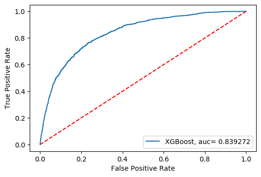

```python
# tpr: defines how many correct positive results occur among all positive samples available during the test.
# fpr: defines how many incorrect positive results occur among all negative samples available during the test.

# plot-roc-curve
fpr, tpr, _ = roc_curve(y_test,  y_pred_proba)
plt.plot(fpr,tpr,label="XGBoost, auc= %f" % auc_y)
plt.plot([0, 1], [0, 1],'r--')
plt.legend(loc=4)
plt.ylabel('True Positive Rate')
plt.xlabel('False Positive Rate')
plt.show()
# https://stackoverflow.com/questions/25009284/how-to-plot-roc-curve-in-python
```

## **5. Test dataset prediction**

```python
# save test ID column
testID = df_test.ID
```

```python
# note the difference between the number of columns in the two datasets
print('test dataset shape:', df_test.shape)
print('train dataset shape:',df_trainFS.shape)
```

```
test dataset shape: (75818, 370)
train dataset shape: (71171, 309)
```

The train dataset was passed by transformations before be applied in machine learning model. So, it's necessary to pass the test dataset by the same transformations. For this, we have a variable called 'cols_of_interest', which has the index of pertinent columns for this purpose.

```python
# checking the number of columns saved
len(cols_of_interest)
```

```
309
```

```python
# Target label droping
cols_of_interest_test = cols_of_interest.iloc[:-1]

# Passing test dataset by the same transformations on train dataset
# Getting the same features of the model created.
new_test = df_test[cols_of_interest_test]
```

```python
# Confirming that the number of columns is the same
# print(y.shape)
print(X.shape)
print(new_test.shape)
```

```
(71171, 308)
(75818, 308)
```

```python
# now, we can predict the result of test dataset
preds = clf.predict_proba(new_test)[:, 1]
preds
```

```
array([0.04666491, 0.05378694, 0.00174499, ..., 0.00365964, 0.07590451,
       0.00125421], dtype=float32)
```

## **Submission**

```python
kaggleSubmission = pd.DataFrame({
    'ID'    : testID,
    'TARGET': preds
})
```

```python
kaggleSubmission.to_csv(r'Project3_XGB_v1.csv', index = False, header=True)
```

Finally, the score received for our XGBoost model by Kaggle was:

- Public Score: 0.83324